# OECDデータによる住宅価格の可視化

日独英米新の例

[岩田真一郎](https://shinichiro-iwata.github.io/)（ [神奈川大学経済学部](https://www.econ.kanagawa-u.ac.jp/)）

2024-03-14作成，2024-03-15改定

# 1 目的

- [OECD](https://www.oecd.org/tokyo/statistics/)の主要統計から住宅価格に関連するデータを抽出し，実質住宅価格指数（real house price indices）を[Natural Earth](https://www.naturalearthdata.com/)の世界地図に可視化．
- [バブルマップ](https://shinichiro-iwata.github.io/geospatial-data-visualization/bubble-map-visualization.html)をアニメーション化．
  - OECDのデータを扱うパッケージが用意されているため，それを利用する．
    - パッケージをインストールする場合は`install.packages("OECD")`ではななく，下記の方がよいかも（作成日現在）．

```r
#インストールが必要な場合
library(devtools)
install_github("expersso/OECD")
```

ライブラリ：`sf`，`tidyverse`，`OECD`，`rnaturalearth`，`gganimate`

```r
library(sf)
library(tidyverse)
#OECDのデータ利用
library(OECD)
#Natural Earth（世界地図）
library(rnaturalearth)
#アニメーション作成
library(gganimate)
```

# 2 データアクセス

- Eric Persson氏作成[サイト](https://github.com/expersso/OECD)を参考に，OECDのデータにアクセス．データのダウンロード時間を短くするため，興味のあるデータに絞る．
1. `get_datasets()`：OECDに掲載されているすべてのデータにアクセス．
2. 膨大なデータであるため，`search_dataset()`を用いて必要なデータを検索．ここでは，キーワードとして「住宅価格（`house price`）」に関わるデータを検索．

```r
oecd <- get_datasets()
search_dataset("house price", data=oecd)
```

| id | title |
| --- | --- |
| HOUSE_PRICES | Analytical house prices indicators |
| RHPI | National and Regional House Price Indices |
| RHPI_TARGET | National and Regional House Price Indices - Headline indicators |

- `↑` 3つの指標があり，それぞれの説明が記されている．
3. 以下では`HOUSE_PRICES`を利用．`hp`と名付ける．
4. `get_data_structure()`：指定されたデータ（`hp`）のリストを返す．各リストの観測数，変数の数を確認できる．`hpstr`と名付ける．
5. `str()`：`hpstr`のデータ構造を表示．そのうち，最初の階層のみ（`max.level=1`）表示．

```r
hp <- "HOUSE_PRICES"
hpstr <- get_data_structure(hp)
str(hpstr, max.level=1)
```

```
## List of 9
##  $ VAR_DESC       :'data.frame': 9 obs. of  2 variables:
##  $ COU            :'data.frame': 52 obs. of  2 variables:
##  $ IND            :'data.frame': 7 obs. of  2 variables:
##  $ TIME           :'data.frame': 476 obs. of  2 variables:
##  $ OBS_STATUS     :'data.frame': 16 obs. of  2 variables:
##  $ UNIT           :'data.frame': 323 obs. of  2 variables:
##  $ POWERCODE      :'data.frame': 32 obs. of  2 variables:
##  $ REFERENCEPERIOD:'data.frame': 112 obs. of  2 variables:
##  $ TIME_FORMAT    :'data.frame': 5 obs. of  2 variables:
```

- `VAR_DESC`の中身を表示．
  - `IND`が住宅価格指標．

```r
hpstr$VAR_DESC
```

| id | description |
| --- | --- |
| COU | Country |
| IND | Indicator |
| TIME | Time |
| OBS_VALUE | Observation Value |
| TIME_FORMAT | Time Format |
| OBS_STATUS | Observation Status |
| UNIT | Unit |
| POWERCODE | Unit multiplier |
| REFERENCEPERIOD | Reference period |

- `IND`の中身を表示．
  - このうち`RHP`（実質住宅価格指数）を利用．
  - 2015年が100．

```r
hpstr$IND
```

| id | label |
| --- | --- |
| RHP | Real house price indices, s.a. |
| HPI | Nominal house price indices, s.a. |
| RPI | Rent prices, s.a. |
| HPI_RPI | Price to rent ratio |
| HPI_RPI_AVG | Standardised price-rent ratio |
| HPI_YDH | Price to income ratio |
| HPI_YDH_AVG | Standardised price-income ratio |

- `COU`の中身を表示．
  - このうち日本（`JPN`），ドイツ（`DEU`），アメリカ（`USA`），イギリス（`GBR`），ニュージーランド（`NZL`）を利用．

```r
hpstr$COU
```

| id | label |
| --- | --- |
| AUS | Australia |
| AUT | Austria |
| BEL | Belgium |
| CAN | Canada |
| CHL | Chile |
| COL | Colombia |
| CRI | Costa Rica |
| CZE | Czechia |
| DNK | Denmark |
| EST | Estonia |

[output cut: 42 more lines]

6. `list()`を用いて，可視化する変数や要素をフィルターの条件としてリスト化．`filter_list`と名付ける．
- 5カ国を`c()`でベクトルとして扱う．
- 他の国も選択したいときは，`↑`表の`id`から3文字の国名コードを加える．

```r
filter_list <-
  list(c("JPN", "DEU", "USA", "GBR", "NZL"),
       "RHP")
```

7. `get_dataset()`：データを指定し，フィルターをかけて，データを抽出．`df`と名付ける．

```r
df <-
  get_dataset(dataset=hp,
              filter=filter_list)

#最初の6行
df %>%
  head()
```

| COU | IND | ObsValue | POWERCODE | TIME_FORMAT | Time | UNIT |
| --- | --- | --- | --- | --- | --- | --- |
| USA | RHP | 55.7439820631505 | 0 | P1Y | 1970 | IDX |
| USA | RHP | 55.5824179804944 | 0 | P1Y | 1970-Q1 | IDX |
| USA | RHP | 55.3819969041801 | 0 | P1Y | 1970-Q2 | IDX |
| USA | RHP | 55.8791006733874 | 0 | P1Y | 1970-Q3 | IDX |
| USA | RHP | 56.1324126945401 | 0 | P1Y | 1970-Q4 | IDX |
| USA | RHP | 57.7873609109132 | 0 | P1Y | 1971 | IDX |

- `↑` `Time`列に四半期データが含まれている．このままだと年次データと識別できない．
  - `TIME_FORMAT`の表示（`↓`）．
    - `P1Y`が年次データ，`P3M`が四半期データとされているが，`↑`の`TIME_FORMAT`はすべて`P1Y`と表示．．．（なぜ？）

```r
hpstr$TIME_FORMAT
```

| id | label |
| --- | --- |
| P1Y | Annual |
| P1M | Monthly |
| P3M | Quarterly |
| P6M | Half-yearly |
| P1D | Daily |

- 仕方ないので，`df`から利用する列を選抜（`select()`）し，`Time`列で「-」表記のある要素（例えば，`1970-Q1`）を取り除く（`fliter()`の`!`で取り除くことが可能）.
  - 参考コード：[Rを利用した経済統計データの取得(3)](https://doi.org/10.14945/00028427)．
  - 最初の6行を表示すると，四半期データが取り除かれていることを確認できる．

```r
df <-
  df %>%
  select(COU, Time, ObsValue) %>%
  filter(!str_detect(Time, "-"))

#最初の6行
df %>%
  head()
```

| COU | Time | ObsValue |
| --- | --- | --- |
| USA | 1970 | 55.7439820631505 |
| USA | 1971 | 57.7873609109132 |
| USA | 1972 | 59.8948007880571 |
| USA | 1973 | 63.5659370358062 |
| USA | 1974 | 62.8566953983266 |
| USA | 1975 | 61.6576257651558 |

8. 実質住宅価格の値（`ObsValue`）が文字なので数値に変更．

- 準備完了．

```r
df <-
  df %>%
  mutate(ObsValue=as.numeric(ObsValue))
```

# 3 可視化

## 3.1 折れ線グラフ

- 世界地図にする前に，折れ線グラフ（`geom_line()`）で可視化．
  - 国ごとにまとめ（`group=COU`），色（`color`）と折れ線の形状（`linetype`）で識別．

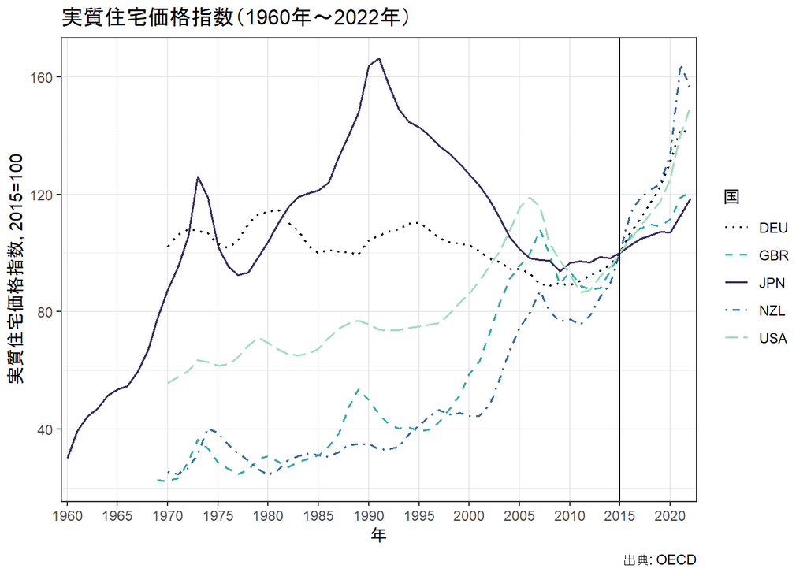

```r
#図を見やすくするための工夫
my_breaks <-
  c(1960, 1965, 1970, 1975, 1980, 1985,
    1990,1995, 2000, 2005, 2010, 2015, 2020)

my_color <-
  c("#0B0405FF", "#38AAACFF", "#3B2F5EFF",
    "#366A9FFF", "#A0DFB9FF")

my_line <-
  c("dotted", "dashed", "solid",
    "dotdash", "longdash")

#可視化
ggplot()+
  geom_line(data=df,
            aes(x=Time, y=ObsValue,
                group=COU, color=COU,
                linetype=COU),
                linewidth=0.7)+
  scale_color_manual(values=my_color)+
  scale_linetype_manual(values=my_line)+
  geom_vline(xintercept="2015",
             linewidth=0.5)+
  scale_x_discrete(breaks=my_breaks)+
  labs(color="国", linetype="国",
       x="年", y="実質住宅価格指数, 2015=100",
       caption="出典: OECD")+
  ggtitle("実質住宅価格指数（1960年～2022年）")+
  theme_bw()
```

## 3.2 世界地図

### 3.2.1 世界地図の読込

- 詳細は[Natural Earthの地理空間データの可視化](https://shinichiro-iwata.github.io/geospatial-data-visualization/rnaturalearth-visualization.html)参照．
  - `ne_countries()`で読込．
  - 地物（オブジェクト）とその属性をもつデータであるためsfクラスを指定．
  - 地図の解像度（`scale`）は`medium`を指示．`World_map`と名付ける．
  - 座標参照系（CRS）：EPSG：4326：WGS84．

```r
World_map<-
  ne_countries(scale="medium",
               returnclass="sf")

#南極大陸削除（好み）
World_map %>%
  filter(iso_a3!="ATA") ->
  World_map
```

### 3.2.2 データ結合

- `World_map`の`iso_a3`が3文字の国名コード．
  - `left_join()`：データ結合（横方向）．

```r
hp_map<-
  left_join(World_map, df,
            by=c("iso_a3"="COU"))
```

### 3.2.3 コロプレスマップのアニメ化

- コロプレスマップで時系列の実質住宅価格指数の変化を捉えるアニメーション作成．
  - アニメーション作成の詳細は[アニメーションによる地理空間データの可視化](https://shinichiro-iwata.github.io/geospatial-data-visualization/DID-data-animation.html)参照．

```r
choropleth_map <-
  ggplot()+
  geom_sf(data=World_map, fill="gray",
          alpha=0.4, color="white",
          linewidth=0.001)+
  geom_sf(data=hp_map, aes(fill=ObsValue),
          color="white", linewidth=0.001)+
  scale_fill_viridis_c(option="G")+
  labs(fill="2015＝100",
       subtitle="年:{current_frame}",
       caption="出典：Natural Earth, OECD")+
  ggtitle("実質住宅価格指数")+
  coord_sf(crs=st_crs("ESRI:54030"))+
  theme_bw()+
  theme(legend.position="bottom")
```

- `transition_manual()`：作成された地図（フレーム）を`Time`で連続して変化させるように指示．`anime_`と名付ける．
  - `animate()`：作成したanimeをアニメーション化．

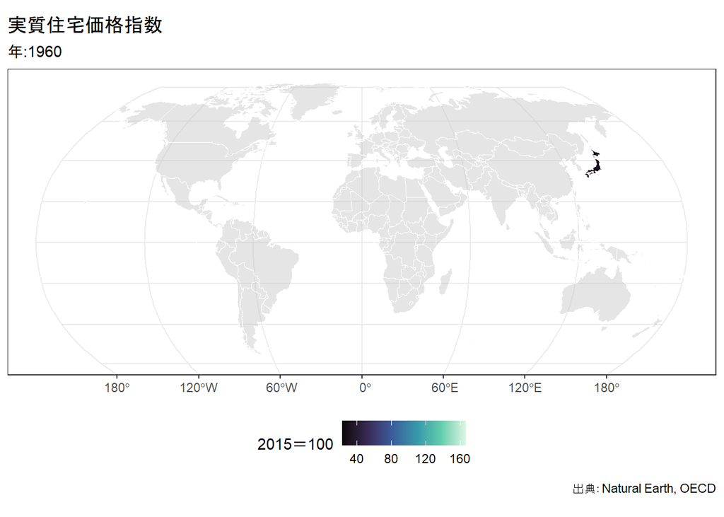

```r
anime_choropleth <-
  choropleth_map+
  transition_manual(Time)

anime_choropleth  %>%
  animate()
```

### 3.2.4 バブルマップのアニメ化

- 最終目標であるバブルマップを作成し，アニメーション化．
  - 実質住宅価格指数を点データとして表現する必要あり．
  - そこで，各国の首都の位置情報を取得．
    - ここでは，[自由に使える首都名・位置情報データ](https://note.com/kentoide/n/n16354c4b3458)から取得．ただし，ダウンロードしたデータの首都名が入る列名`name`をデータ結合上`capital_name`に変更．
    - `hp_map`に首都の位置情報を追加するために，データ結合．
  - 世界地図は背景として利用．

```r
#首都の位置情報
capital <-
  read.csv("capital_cities_2022_0.csv",
           sep=",", header=TRUE)

#データ結合
hp_map <-
  left_join(hp_map, capital,
            by=c("iso_a3"="adm0_a3"))

#データの一部中身，位置情報
hp_map %>%
  select(iso_a3, Time, capital_name,
         x, y) %>%
  filter(Time=="2022") ->
  hp_map_XY

hp_map_XY %>%
  head()
```

|  | iso_a3 | Time | capital_name | x | y | geometry |
| --- | --- | --- | --- | --- | --- | --- |
| 1 | DEU | 2022 | Berlin | 13.3996028 | 52.52376 |  |
| 2 | GBR | 2022 | London | -0.1186677 | 51.50194 |  |
| 3 | JPN | 2022 | Tokyo | 139.7494616 | 35.68696 |  |
| 4 | NZL | 2022 | Wellington | 174.7832659 | -41.29999 |  |
| 5 | USA | 2022 | Washington, D.C. | -77.0113644 | 38.90150 |  |

- バブルマップ作成の詳細は[バブルマップによる地価の可視化](https://shinichiro-iwata.github.io/geospatial-data-visualization/bubble-map-visualization.html)参照．
  - とりあえず，バブルマップを6年分作成し，可視化．

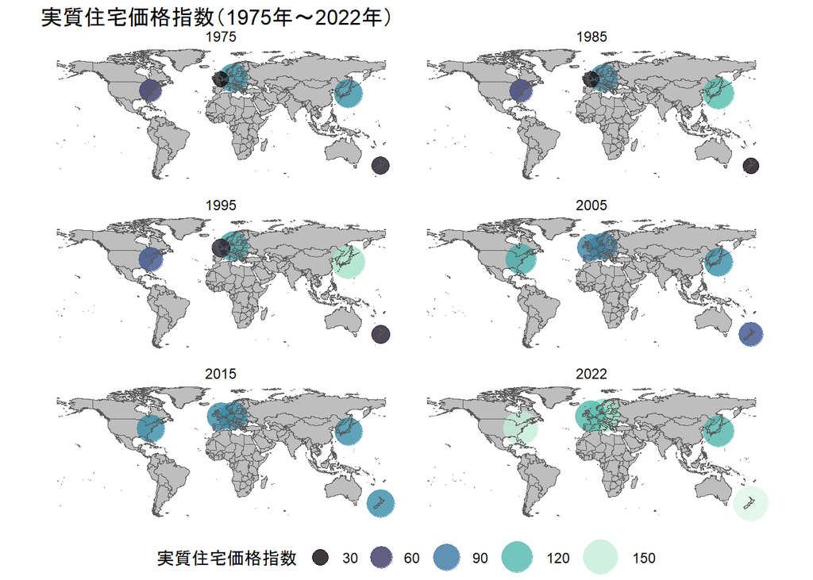

```r
#6年分抽出
hp_map %>%
  filter(Time=="1975" | Time=="1985" |
           Time=="1995" | Time=="2005" |
           Time=="2015" | Time=="2022") ->
  hp_map2

#可視化
ggplot()+
  geom_sf(data=World_map, fill="gray")+
  geom_point(data=hp_map2, aes(x=x, y=y,
              color=ObsValue,
              size=ObsValue), alpha=0.8)+
  scale_color_viridis_c(option="G",
                      guide="legend")+
  scale_size_area(max_size=10)+
  geom_sf(data=World_map, fill="NA")+
  labs(color="実質住宅価格指数",
       size="実質住宅価格指数",
       x="", y="")+
  facet_wrap(~Time, ncol=2)+
  ggtitle("実質住宅価格指数（1975年～2022年）")+
  theme_void()+
  theme(legend.position="bottom")
```

- アニメーション作成．

```r
#bubble_mapと名付けて地図を格納
bubble_map <-
  ggplot()+
  geom_sf(data=World_map, fill="gray")+
  geom_point(data=hp_map,
             aes(x=x, y=y,
              color=ObsValue,
              size=ObsValue),
             alpha=0.8)+
  scale_color_viridis_c(option="G",
                        guide="legend")+
  scale_size_area(max_size=16)+
  geom_sf(data=World_map, fill="NA")+
  labs(color="実質住宅価格指数",
       size="実質住宅価格指数",
       subtitle="年:{current_frame}",
       caption="出典：Natural Earth, OECD",
       x="", y="")+
  ggtitle("実質住宅価格指数（2015=100）")+
  theme_void()+
  theme(legend.position="bottom")
```

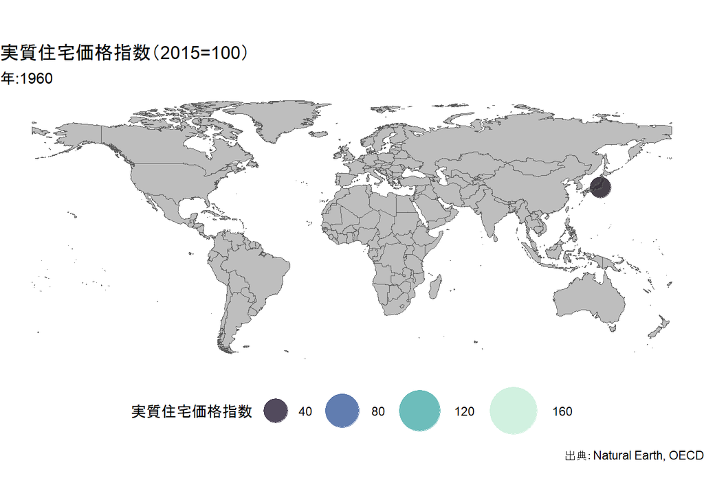

```r
#アニメーション化準備
anime_bubble <-
  bubble_map+
  transition_manual(Time)

#アニメーション化
anime_bubble %>%
  animate()
```

# 4 参考ウェブサイト・文献

- expersso/OECD（アクセス日：2024-03-14）
- [自由に使える首都名・位置情報データ](https://note.com/kentoide/n/n16354c4b3458)（アクセス日：2024-03-14）
- 遠山弘徳（2021）[「 Rを利用した経済統計データの取得(3)」](https://doi.org/10.14945/00028427)『静岡大学経済研究』巻26号2, 37-61

**Rによる地理空間データの可視化**

- チュートリアル[ホーム](https://shinichiro-iwata.github.io/geospatial-data-visualization/)
  - [バブルマップによる地価の可視化](https://shinichiro-iwata.github.io/geospatial-data-visualization/bubble-map-visualization.html)
  - [Natural Earthの地理空間データの可視化](https://shinichiro-iwata.github.io/geospatial-data-visualization/rnaturalearth-visualization.html)
  - [アニメーションによる地理空間データの可視化](https://shinichiro-iwata.github.io/geospatial-data-visualization/DID-data-animation.html)